# No-Show Appointment Prediction

## Introduction

No-shows costs billions to healthcare systems across the world, in the US alone, they account for [$150 billion](http://customerthink.com/how-healthcare-providers-can-stop-losing-thousands-of-dollars-to-no-shows/) wasted every year.

This kernel will train on historical data using predictive modelling to determine if a client will show up or not for an appointment.

```r
glimpse(show.raw.data)
```

```
## Observations: 110,527
## Variables: 16
## $ PatientId      <dbl> 2.987250e+13, 5.589978e+14, 4.262962e+12, 8.679...
## $ AppointmentID  <dbl> 5642903, 5642503, 5642549, 5642828, 5642494, 56...
## $ Gender         <chr> "F", "M", "F", "F", "F", "F", "F", "F", "F", "F...
## $ ScheduledDay   <date> 2016-04-29, 2016-04-29, 2016-04-29, 2016-04-29...
## $ AppointmentDay <date> 2016-04-29, 2016-04-29, 2016-04-29, 2016-04-29...
## $ Age            <dbl> 62, 56, 62, 8, 56, 76, 23, 39, 21, 19, 30, 29, ...
## $ Neighbourhood  <chr> "JARDIM DA PENHA", "JARDIM DA PENHA", "MATA DA ...
## $ Scholarship    <dbl> 0, 0, 0, 0, 0, 0, 0, 0, 0, 0, 0, 0, 1, 0, 0, 0,...
## $ Hipertension   <dbl> 1, 0, 0, 0, 1, 1, 0, 0, 0, 0, 0, 0, 0, 0, 0, 0,...
## $ Diabetes       <dbl> 0, 0, 0, 0, 1, 0, 0, 0, 0, 0, 0, 0, 0, 0, 0, 0,...
## $ Alcoholism     <dbl> 0, 0, 0, 0, 0, 0, 0, 0, 0, 0, 0, 0, 0, 0, 0, 0,...
## $ Handcap        <dbl> 0, 0, 0, 0, 0, 0, 0, 0, 0, 0, 0, 0, 0, 0, 0, 0,...
## $ SMS_received   <dbl> 0, 0, 0, 0, 0, 0, 0, 0, 0, 0, 0, 1, 0, 0, 0, 1,...
## $ `No-show`      <chr> "No", "No", "No", "No", "No", "No", "Yes", "Yes...
## $ AwaitingTime2  <drtn> 0 days, 0 days, 0 days, 0 days, 0 days, -2 day...
## $ Status         <chr> "No", "No", "No", "No", "No", "No", "Yes", "Yes...
```

## Exploratory Data Analysis

Next, we shall filter numeric columns for correlation and visualize the results using ‘corrgram’ & ‘corrplot’ packages to show features that are highly correlated.

```r
# Encode target variable as numeric
show.raw.data$Status.numeric = as.numeric(ifelse(show.raw.data$`No-show`=="Yes",1,0))

# Find all numerical vars in dataframe
numerical.vars = sapply(show.raw.data, is.numeric)

# Dataframe showing correlation between the each numerical variables
cor.data <- cor(show.raw.data[numerical.vars])
print(cor.data)
```

```
##                   PatientId AppointmentID          Age  Scholarship
## PatientId       1.000000000    0.00403857 -0.004139395 -0.002880234
## AppointmentID   0.004038570    1.00000000 -0.019126498  0.022614891
## Age            -0.004139395   -0.01912650  1.000000000 -0.092457153
## Scholarship    -0.002880234    0.02261489 -0.092457153  1.000000000
## Hipertension   -0.006441074    0.01275225  0.504586253 -0.019728790
## Diabetes        0.001605323    0.02262835  0.292391464 -0.024893532
## Alcoholism      0.011011492    0.03294394  0.095811282  0.035022469
## Handcap        -0.007916049    0.01410562  0.078033201 -0.008586276
## SMS_received   -0.009749464   -0.25661845  0.012643417  0.001194013
## Status.numeric -0.001461300   -0.16260212 -0.060318511  0.029135031
##                Hipertension     Diabetes    Alcoholism      Handcap
## PatientId      -0.006441074  0.001605323  0.0110114921 -0.007916049
## AppointmentID   0.012752246  0.022628349  0.0329439381  0.014105625
## Age             0.504586253  0.292391464  0.0958112821  0.078033201
## Scholarship    -0.019728790 -0.024893532  0.0350224694 -0.008586276
## Hipertension    1.000000000  0.433085642  0.0879707981  0.080083308
## Diabetes        0.433085642  1.000000000  0.0184735021  0.057529989
## Alcoholism      0.087970798  0.018473502  1.0000000000  0.004647652
## Handcap         0.080083308  0.057529989  0.0046476522  1.000000000
## SMS_received   -0.006266863 -0.014550032 -0.0261473882 -0.024160920
## Status.numeric -0.035701177 -0.015179944 -0.0001960437 -0.006076212
##                SMS_received Status.numeric
## PatientId      -0.009749464  -0.0014612998
## AppointmentID  -0.256618449  -0.1626021249
## Age             0.012643417  -0.0603185114
## Scholarship     0.001194013   0.0291350313
## Hipertension   -0.006266863  -0.0357011773
## Diabetes       -0.014550032  -0.0151799438
## Alcoholism     -0.026147388  -0.0001960437
## Handcap        -0.024160920  -0.0060762123
## SMS_received    1.000000000   0.1264306576
## Status.numeric  0.126430658   1.0000000000
```

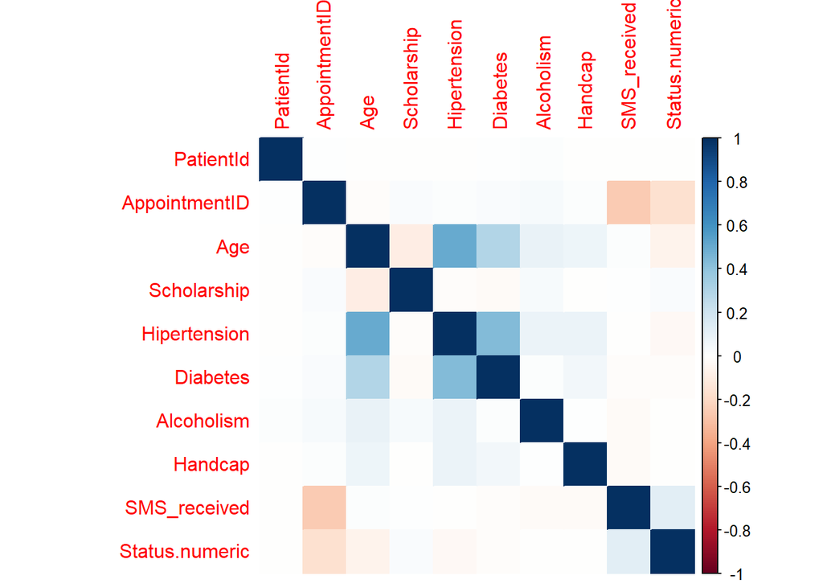

```r
## Plot Correlation dataframe
corrplot(cor.data, method = 'color')
```

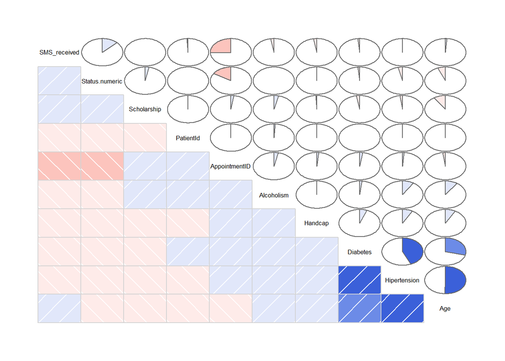

```r
## correlogram helps to visualize variables that are highly correlated (i.e A full pie chart equals a perfect correlation)
corrgram(show.raw.data, order=TRUE, lower.panel = panel.shade, upper.panel = panel.pie, text.panel = panel.txt)
```

The Correlation plot are usefull for identifying linear relationships. In this scenario, the interesting pattern about `Status` is that no varible appears to have a linear relationship. Apart from this, we can see correlations between age, Hipertension, and diabetes. Another interesting variable is `SMS_received`.

Let’s start by looking how Age behaves in regards to `Status`.

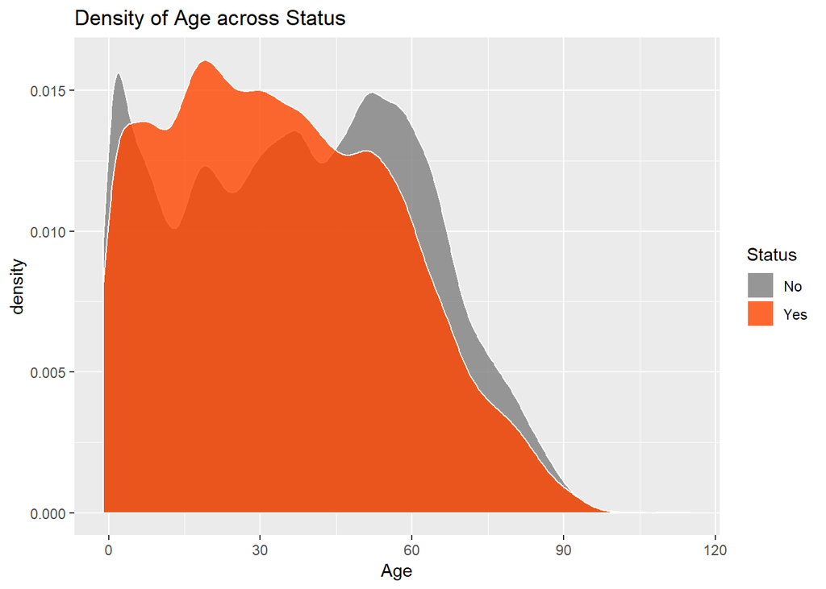

Age seems to influence positively the occurence of our target variable (Status) in age groups of 10~40 years and negative influence on groups of anything above, hence it’s near zero correlation. Let’s split into age groups to have a closer look.

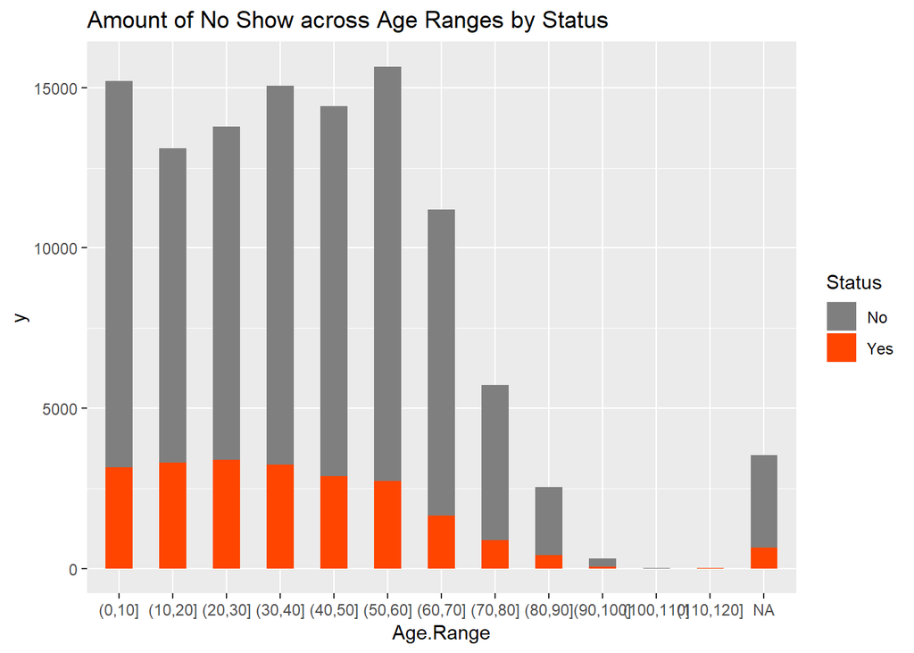

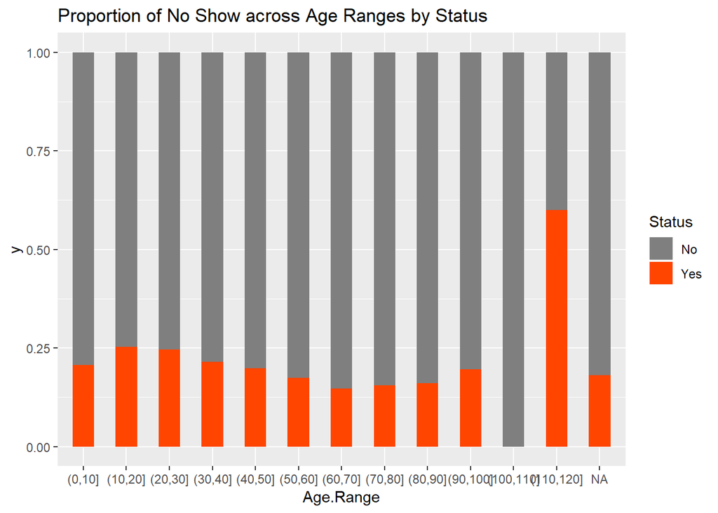

The groups above 90 years should be disregarded in the analysis, given the small amount of observations, other than that we can observe how ages ranging between 10 and 20 are almost twice as likely to miss a medical appointment than somebody within the range of 60 to 70 years old.

Another interesting finding is the `NA` group, they are the result of trying to assign age of 0 to groups and represent missing data.

```r
sum(show.raw.data$Age == 0)
```

```
## [1] 3539
```

Next, we’ll have a look at `SMS_received` variable:

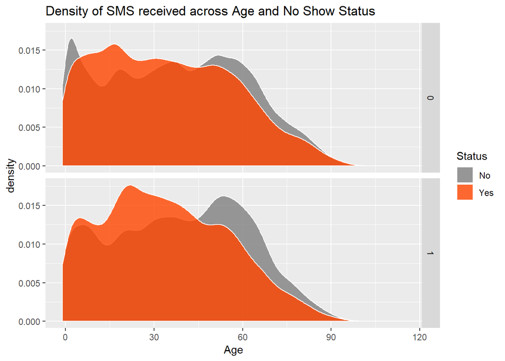

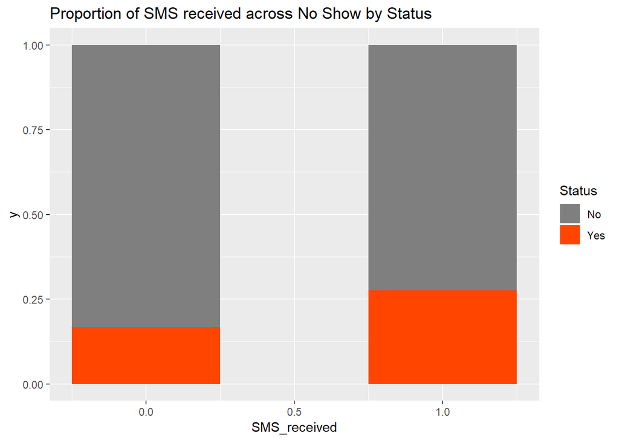

By evaluating SMS alongside `Age`, we see an interesting pattern, where **sending SMS actually increases the likelihood of a patient not showing**, such effect is more prominent on age groups 10~40.

Next, we’ll look at how `Neighbourhood` influences:

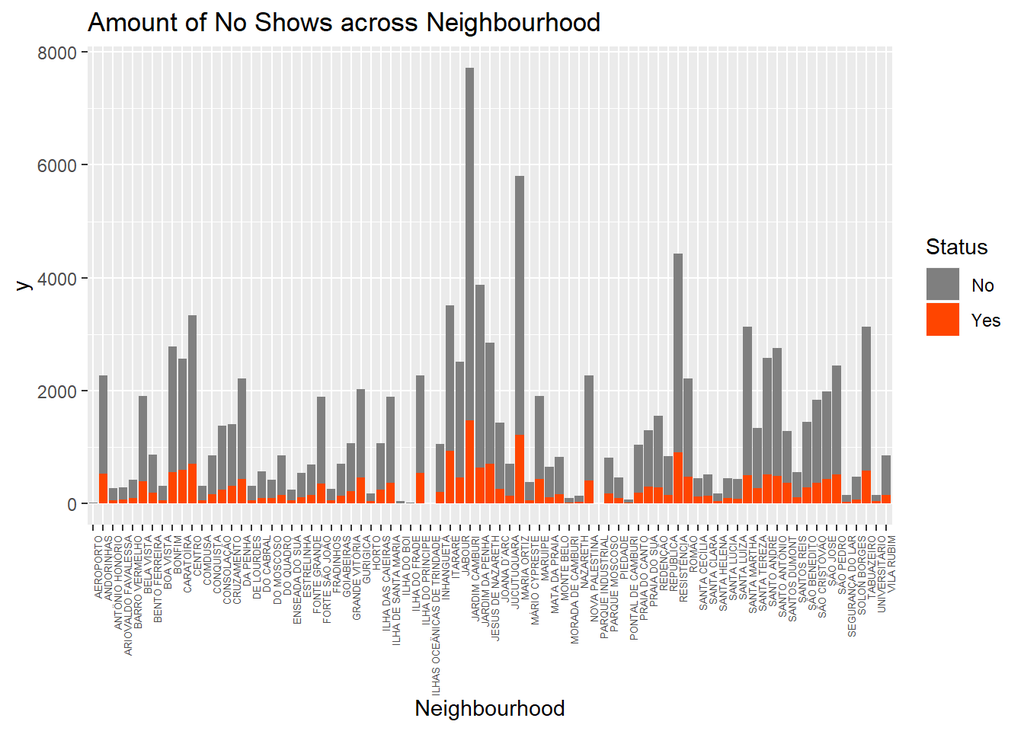

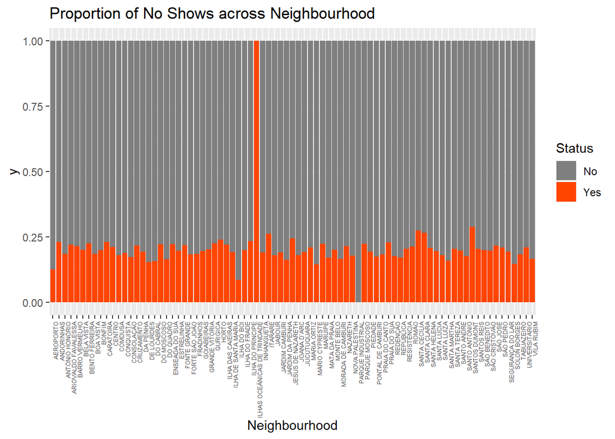

The neighbourhood seems to have an effect with no shows, another deep dive analysis could to use this information to engineer the distance traveled to the medical exam, **maybe offer transportation service to their appointments**.

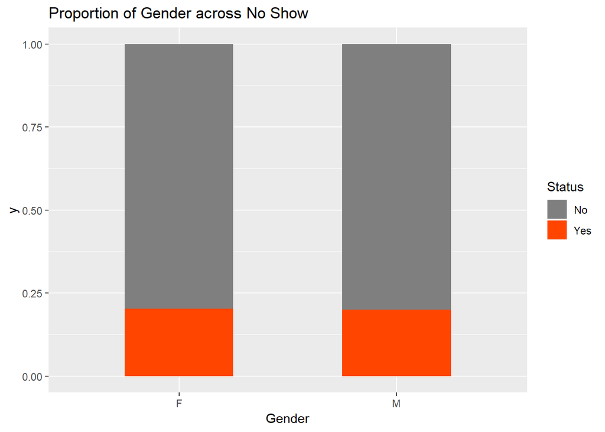

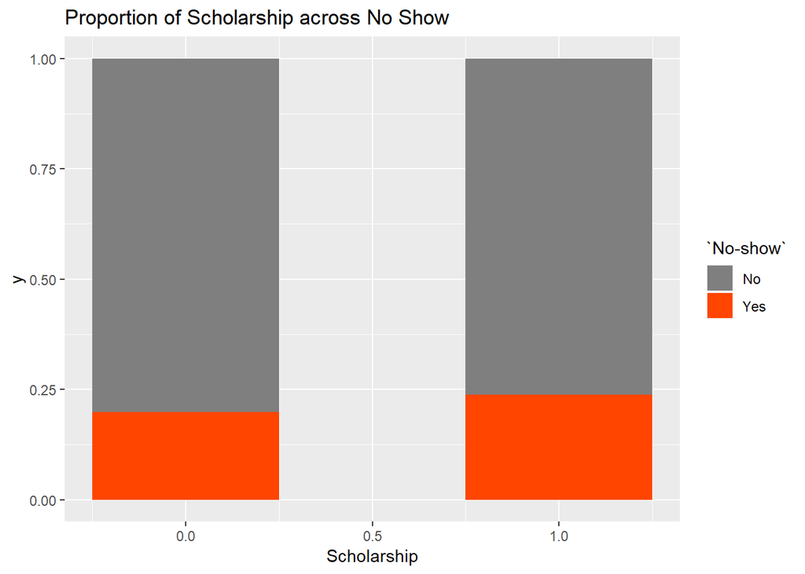

`Scholarship` has an interesting effect on no shows, it appears that people with such variable are more prone to not showing on a medical exam. `Scholarship` in this dataset actually refers to a social wellfare program of the Brazilian goverment that aids poor families - it gave the suspition that an **income** related variable could play an interesting role in predicting no shows.

# Feature Engineering to clean some variables

```r
#===============================================================
# [1] Predictive Modeling # 1: Support Vector Machine (SVM)
#===============================================================
# Remove unecessary columns, change var types to factor

showtime3 <- show.raw.data


showtime3$AwaitingTime2<-abs(showtime3$AwaitingTime2)

showtime3$Sex <-ifelse(showtime3$Gender =="F", 1, 0)
is.numeric(showtime3$Sex)
```

```
## [1] TRUE
```

```r
showtime3$Status<- as.factor(showtime3$Status)
showtime3$Visit<- ifelse(showtime3$Status == "Yes", 1, 0)

is.numeric(showtime3$Visit)
```

```
## [1] TRUE
```

```r
#showtime3$AppointmentDay <-  as.POSIXlt(showtime3$ApointmentDay)

#showtime3$ApointmentMonth <- month(showtime3$ApointmentData,label = TRUE)
#as.numeric(showtime3$ApointmentMonth)
showtime3$AwaitingTime2 <- as.numeric(showtime3$AwaitingTime2)
is.numeric(showtime3$AwaitingTime2)
```

```
## [1] TRUE
```

```r
#check data frame for missing data and insert 0 value insted of NA
showtime3[is.na(showtime3)] <-0
### choose random sample for data
data.sample <- sample_n(showtime3, 200)
data.sample$Visit <- factor(data.sample$Visit)
#select columns to use for prediction
data.sample.use <- data.sample %>% select(1:13,15,19,20)


#split the data to train and test sets
set.seed(1234)
sample <- sample.split(data.sample.use$Visit,0.7)
# 70% of data = train
train <- subset(data.sample.use, sample==T)
# 30% = test
test <- subset(data.sample.use, sample==F)


#TRAIN SVM
#model.one <- svm(Visit ~ Age+Sex+AwaitingTime2, data = train)
#summary(model.one)

# Tune Parameters
tuned.results <- tune(svm,train.x = Visit ~ Age+Sex+AwaitingTime2, data = train, kernel ='radial',ranges = list(cost=c(100,200),gamma=c(0.1)))
print(summary(tuned.results))
```

```
##
## Parameter tuning of 'svm':
##
## - sampling method: 10-fold cross validation
##
## - best parameters:
##  cost gamma
##   100   0.1
##
## - best performance: 0.2428571
##
## - Detailed performance results:
##   cost gamma     error dispersion
## 1  100   0.1 0.2428571 0.07678341
## 2  200   0.1 0.2428571 0.09035079
```

```r
# Detailed performance results:
#  cost gamma     error dispersion
#  100   0.1 0.2857143 0.08908708
#  200   0.1 0.3071429 0.10674529

#Train SVM Model
tuned.model <- svm(Visit ~ Age+Sex+AwaitingTime2, data = train, cost=200, gamma=0.1)


#pass in the 'test data' without the column to be predicted.
tuned.predictions <- predict(tuned.model, test[1:15])
table(tuned.predictions, test$Visit)
```

```
##
## tuned.predictions  0  1
##                 0 45 12
##                 1  3  0
```

```r
#output predicted values
output.show <- data.frame(test$PatientId,test$Visit, tuned.predictions)
head(output.show)
```

```
##    test.PatientId test.Visit tuned.predictions
## 6    2.835222e+12          0                 0
## 7    9.981638e+12          0                 0
## 11   2.519284e+13          0                 0
## 14   9.547470e+13          0                 0
## 18   2.477612e+14          0                 0
## 20   2.439367e+09          0                 0
```

```r
#Check the accuracy Using Confussion Matrix:
caret::confusionMatrix(tuned.predictions, test$Visit)
```

```
## Confusion Matrix and Statistics
##
##           Reference
## Prediction  0  1
##          0 45 12
##          1  3  0
##
##                Accuracy : 0.75
##                  95% CI : (0.6214, 0.8528)
##     No Information Rate : 0.8
##     P-Value [Acc > NIR] : 0.86938
##
##                   Kappa : -0.087
##
##  Mcnemar's Test P-Value : 0.03887
##
##             Sensitivity : 0.9375
##             Specificity : 0.0000
##          Pos Pred Value : 0.7895
##          Neg Pred Value : 0.0000
##              Prevalence : 0.8000
##          Detection Rate : 0.7500
##    Detection Prevalence : 0.9500
##       Balanced Accuracy : 0.4688
##
##        'Positive' Class : 0
##
```

```r
agreement <- tuned.predictions == test$Visit
prop.table(table(agreement))
```

```
## agreement
## FALSE  TRUE
##  0.25  0.75
```

```r
#==================================
# [2] Predictive Modeling #2: KERNEL SVM
#==================================

kern.model <- ksvm(Visit ~ Age+Sex+AwaitingTime2, data = train, kernel="vanilladot")
#output.show <- data.frame(test$PatientId,test$Visit, tuned.predictions)
#head(output.show)

kernlab.predictions <- predict(kern.model, test[1:15])

output.show.kernlab <- data.frame(test$PatientId,test$Visit, kernlab.predictions)
head(output.show.kernlab)
```

```
##   test.PatientId test.Visit kernlab.predictions
## 1   2.835222e+12          0                   0
## 2   9.981638e+12          0                   0
## 3   2.519284e+13          0                   0
## 4   9.547470e+13          0                   0
## 5   2.477612e+14          0                   0
## 6   2.439367e+09          0                   0
```

```r
caret::confusionMatrix(kernlab.predictions, test$Visit)
```

```
## Confusion Matrix and Statistics
##
##           Reference
## Prediction  0  1
##          0 48 12
##          1  0  0
##
##                Accuracy : 0.8
##                  95% CI : (0.6767, 0.8922)
##     No Information Rate : 0.8
##     P-Value [Acc > NIR] : 0.576440
##
##                   Kappa : 0
##
##  Mcnemar's Test P-Value : 0.001496
##
##             Sensitivity : 1.0
##             Specificity : 0.0
##          Pos Pred Value : 0.8
##          Neg Pred Value : NaN
##              Prevalence : 0.8
##          Detection Rate : 0.8
##    Detection Prevalence : 1.0
##       Balanced Accuracy : 0.5
##
##        'Positive' Class : 0
##
```

```r
agreement.kern <- kernlab.predictions == test$Visit
prop.table(table(agreement.kern))
```

```
## agreement.kern
## FALSE  TRUE
##   0.2   0.8
```

```r
#=============================================================================================================================================
# [3] Predictive Modeling #3: Using LINEAR REGRESSION
#=============================================================================================================================================
# Build the Model to train on the variables
set.seed(1234)
df.lm <- showtime3 %>% select(PatientId, AppointmentID, Gender, ScheduledDay, AppointmentDay, Age, Scholarship, Hipertension, Diabetes, Alcoholism, Handcap, SMS_received, AwaitingTime2, Visit)

# Split up sample
sample.lm <- sample.split(df.lm$Visit, SplitRatio = 0.7)
# 70% of data = train
train.lm <- subset(df.lm, sample==TRUE)
# 30% of data = test
test.lm <- subset(df.lm, sample==FALSE)

# Train and Build the Model
model.lm <- lm(Visit ~ ., data = train.lm)
summary(model.lm)
```

```
##
## Call:
## lm(formula = Visit ~ ., data = train.lm)
##
## Residuals:
##     Min      1Q  Median      3Q     Max
## -0.9330 -0.2117 -0.1552 -0.1012  0.9599
##
## Coefficients:
##                  Estimate Std. Error t value Pr(>|t|)
## (Intercept)     6.954e+00  1.884e+01   0.369 0.712042
## PatientId      -5.452e-19  5.504e-18  -0.099 0.921096
## AppointmentID  -2.204e-07  3.285e-07  -0.671 0.502244
## GenderM        -2.240e-03  3.027e-03  -0.740 0.459430
## ScheduledDay    1.078e-01  3.107e-02   3.470 0.000520 ***
## AppointmentDay -1.082e-01  3.104e-02  -3.484 0.000494 ***
## Age            -1.143e-03  7.226e-05 -15.816  < 2e-16 ***
## Scholarship     4.164e-02  4.819e-03   8.640  < 2e-16 ***
## Hipertension   -5.743e-03  4.393e-03  -1.307 0.191124
## Diabetes        1.989e-02  6.100e-03   3.260 0.001113 **
## Alcoholism      3.080e-02  8.423e-03   3.657 0.000256 ***
## Handcap         2.662e-03  8.846e-03   0.301 0.763512
## SMS_received    5.579e-02  3.315e-03  16.832  < 2e-16 ***
## AwaitingTime2   1.113e-01  3.105e-02   3.584 0.000338 ***
## ---
## Signif. codes:  0 '***' 0.001 '**' 0.01 '*' 0.05 '.' 0.1 ' ' 1
##
## Residual standard error: 0.3926 on 77362 degrees of freedom
## Multiple R-squared:  0.04358,    Adjusted R-squared:  0.04342
## F-statistic: 271.2 on 13 and 77362 DF,  p-value: < 2.2e-16
```

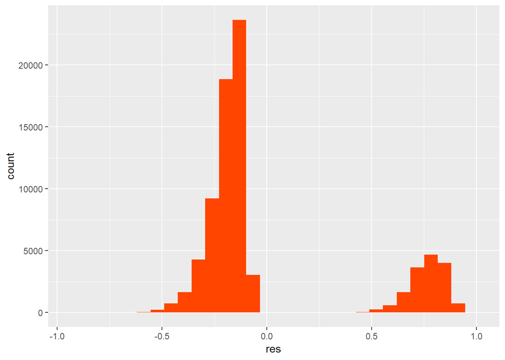

```r
# Interpretation
# Note: FOr most regressions, you want the residuals to look like a Normal Distribution when you plot it.
# Estimate - Is the value of slope calculated by the regression.
# Std. Error - Is a measure of the variability in the Estimate of the Coefficients. Rule of thumb, value must be less than the Coefficient Estimate. lower the better
# t Value -  Is a score that measures whether or not the coefficient for the variable is meaningful for the model.
# Probability or P value - Is the probability that the variable/column is not relevant or signifcant. You want it as small as possible. The more star the more significance.

# Also, R Squared value is a metric for evaluating the 'Goodness of Fit' of the model. Higher is better with 1 being the best. High R squared indicates good correlation but Correlation is not always Causation.

# Plot the Residuals
res <- residuals(model.lm)
res <- as.data.frame(res)

ggplot(res, aes(res)) + geom_histogram(fill="orangered", aplha=0.5)
```

```r
#write.csv(output, file = 'SVM_SolutionV4.csv', row.names = F)
```

Replace ‘Sex’ with ‘Scholarship’ variable

```r
train.lm <- subset(df.lm, sample==TRUE)
# 30% of data = test
test.lm <- subset(df.lm, sample==FALSE)

showtime4 <- df.lm


### choose random sample for data
data.sample4 <- sample_n(showtime4, 1000)
data.sample4$Visit <- factor(data.sample4$Visit)
#data.sample4$Age <- factor(data.sample4$Visit)
#data.sample4$Visit <- factor(data.sample4$Visit)
#select columns to use for prediction
#data.sample.use <- data.sample %>% select(1:13,15,19,20)


#split the data to train and test sets
set.seed(1234)
sample4 <- sample.split(data.sample4$Visit,0.7)
# 70% of data = train
train4 <- subset(data.sample4, sample4==T)
# 30% = test
test4 <- subset(data.sample4, sample4==F)


#TRAIN SVM
#model.one <- svm(Visit ~ Age+Sex+AwaitingTime2, data = train)
#summary(model.one)

# Tune Parameters
tuned.results4 <- tune(svm,train.x = Visit ~ Age+Scholarship+AwaitingTime2, data = train4, kernel ='radial',ranges = list(cost=c(100,200),gamma=c(0.1)))
print(summary(tuned.results4))
```

```
##
## Parameter tuning of 'svm':
##
## - sampling method: 10-fold cross validation
##
## - best parameters:
##  cost gamma
##   200   0.1
##
## - best performance: 0.1957143
##
## - Detailed performance results:
##   cost gamma     error dispersion
## 1  100   0.1 0.1971429 0.04846861
## 2  200   0.1 0.1957143 0.04858543
```

```r
# Detailed performance results:
#  cost gamma     error dispersion
#  100   0.1 0.2857143 0.08908708
#  200   0.1 0.3071429 0.10674529

#Train SVM Model
tuned.model4 <- svm(Visit ~ Age+Scholarship+AwaitingTime2, data = train4, cost=200, gamma=0.1)


#pass in the 'test data' without the column to be predicted.
tuned.predictions4 <- predict(tuned.model4, test4[1:13])
table(tuned.predictions4, test4$Visit)
```

```
##
## tuned.predictions4   0   1
##                  0 242  57
##                  1   0   1
```

```r
#output predicted values
output.show4 <- data.frame(test4$PatientId,test4$Visit, tuned.predictions4)
head(output.show4)
```

```
##    test4.PatientId test4.Visit tuned.predictions4
## 5     9.279890e+13           0                  0
## 15    1.132181e+13           0                  0
## 18    4.842935e+11           0                  0
## 27    2.322975e+12           1                  0
## 32    3.852296e+12           0                  0
## 34    4.149298e+10           0                  0
```

```r
#Check the accuracy Using Confussion Matrix:
caret::confusionMatrix(tuned.predictions4, test4$Visit)
```

```
## Confusion Matrix and Statistics
##
##           Reference
## Prediction   0   1
##          0 242  57
##          1   0   1
##
##                Accuracy : 0.81
##                  95% CI : (0.761, 0.8528)
##     No Information Rate : 0.8067
##     P-Value [Acc > NIR] : 0.4768
##
##                   Kappa : 0.0275
##
##  Mcnemar's Test P-Value : 1.195e-13
##
##             Sensitivity : 1.00000
##             Specificity : 0.01724
##          Pos Pred Value : 0.80936
##          Neg Pred Value : 1.00000
##              Prevalence : 0.80667
##          Detection Rate : 0.80667
##    Detection Prevalence : 0.99667
##       Balanced Accuracy : 0.50862
##
##        'Positive' Class : 0
##
```

```r
agreement4 <- tuned.predictions4 == test4$Visit
prop.table(table(agreement4))
```

```
## agreement4
## FALSE  TRUE
##  0.19  0.81
```

```r
#==================================
# Predictive Modeling #2: KERNEL SVM
#==================================

kern.model4 <- ksvm(Visit ~ Age+Scholarship+AwaitingTime2, data = train4, kernel="vanilladot")
kernlab.predictions4 <- predict(kern.model4, test4[1:13])
output.show5 <- data.frame(test4$PatientId,test4$Visit, kernlab.predictions4)
head(output.show5)
```

```
##   test4.PatientId test4.Visit kernlab.predictions4
## 1    9.279890e+13           0                    0
## 2    1.132181e+13           0                    0
## 3    4.842935e+11           0                    0
## 4    2.322975e+12           1                    0
## 5    3.852296e+12           0                    0
## 6    4.149298e+10           0                    0
```

```r
caret::confusionMatrix(kernlab.predictions4, test4$Visit)
```

```
## Confusion Matrix and Statistics
##
##           Reference
## Prediction   0   1
##          0 242  58
##          1   0   0
##
##                Accuracy : 0.8067
##                  95% CI : (0.7574, 0.8498)
##     No Information Rate : 0.8067
##     P-Value [Acc > NIR] : 0.535
##
##                   Kappa : 0
##
##  Mcnemar's Test P-Value : 7.184e-14
##
##             Sensitivity : 1.0000
##             Specificity : 0.0000
##          Pos Pred Value : 0.8067
##          Neg Pred Value :    NaN
##              Prevalence : 0.8067
##          Detection Rate : 0.8067
##    Detection Prevalence : 1.0000
##       Balanced Accuracy : 0.5000
##
##        'Positive' Class : 0
##
```

```r
agreement.kern4 <- kernlab.predictions4 == test4$Visit
prop.table(table(agreement.kern4))
```

```
## agreement.kern4
##     FALSE      TRUE
## 0.1933333 0.8066667
```